# 09_analysis

## AUC-ROC Curves for the Ensemble Model

The ROC curve is a graphical representation of the performance of a classification model at different threshold levels. It plots the True Positive Rate (TPR) against the False Positive Rate (FPR).

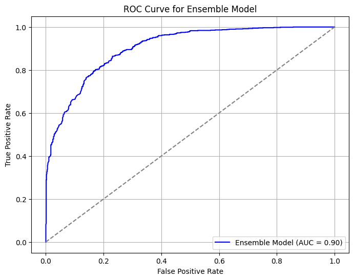

```python
# Predict probabilities for the positive class
y_pred_proba_val = ensemble_df.predict_proba(X_val_processed)[:, 1]

# Calculate the ROC curve
fpr, tpr, thresholds = roc_curve(y_val, y_pred_proba_val)

# Calculate AUC score
roc_auc = roc_auc_score(y_val, y_pred_proba_val)

# Plot the ROC curve
plt.figure(figsize=(8, 6))
plt.plot(fpr, tpr, color='blue', label=f"Ensemble Model (AUC = {roc_auc:.2f})")
plt.plot([0, 1], [0, 1], color='gray', linestyle='--')
plt.xlabel("False Positive Rate")
plt.ylabel("True Positive Rate")
plt.title("ROC Curve for Ensemble Model")
plt.legend(loc="lower right")
plt.grid(True)
plt.show()
```

**Conclusion AUC-ROC Curve**

The ROC curve for the ensemble model demonstrates its performance in distinguishing between the “Transported” and “Not Transported” classes. The model achieves an AUC (Area Under the Curve) score of 0.90, indicating a strong level of discriminative power. This means the model is effective at balancing true positives and false positives across different threshold values. The curve’s proximity to the top-left corner reflects the model’s capacity to achieve a high true positive rate with a relatively low false positive rate, suggesting reliable predictive capability on the validation set.

## Generating Predictions for Test Set and Preparing Submission File

```python
# Disable flake8 for this cell
# flake8: noqa

# Apply the preprocessor (fitted on X_train) to test_df
X_test_processed = preprocessor.transform(test_df)

# Generate predictions and probabilities for the test set
y_pred_ensemble_test = ensemble_df.predict(X_test_processed)
y_pred_proba_ensemble_test = ensemble_df.predict_proba(X_test_processed)[:, 1]

# Ensure that 'PassengerId' exists in test_df for submission
submission_df = pd.DataFrame({
    'PassengerId': test_df['PassengerId'],
    'Transported': y_pred_ensemble_test
})

# Convert 'Transported' predictions to boolean format if not already
submission_df['Transported'] = submission_df['Transported'].astype(bool)

# Save the DataFrame to a CSV file in the required format
submission_df.to_csv('submission_f05.csv', index=False)

print("Submission file 'submission_f05.csv' "
      f"created with the following structure:")
print(submission_df.head())
```

```
Submission file 'submission_f05.csv' created with the following structure:
  PassengerId  Transported
0     0013_01         True
1     0018_01        False
2     0019_01         True
3     0021_01         True
4     0023_01         True
```

### Final Conclusion

This project successfully developed a machine learning pipeline for predicting the transported status of passengers, leveraging a variety of advanced techniques, including data preprocessing, feature engineering, hyperparameter tuning, and an ensemble of powerful models (Gradient Boosting, CatBoost, and LightGBM).

Moreover, model explainability using LIME provided localized insights, showing which features most influenced predictions for individual cases. The ROC curve also demonstrated the ensemble’s high discriminative power, with the model consistently outperforming a random classifier.

The use of AutoML (H2O) allowed for benchmarking the ensemble model against multiple automatically tuned models, confirming that the manually tuned ensemble was among the top-performing approaches.

The final submission achieved 0.79378, according to the Kaggle evaluation, as per the screenshot below:

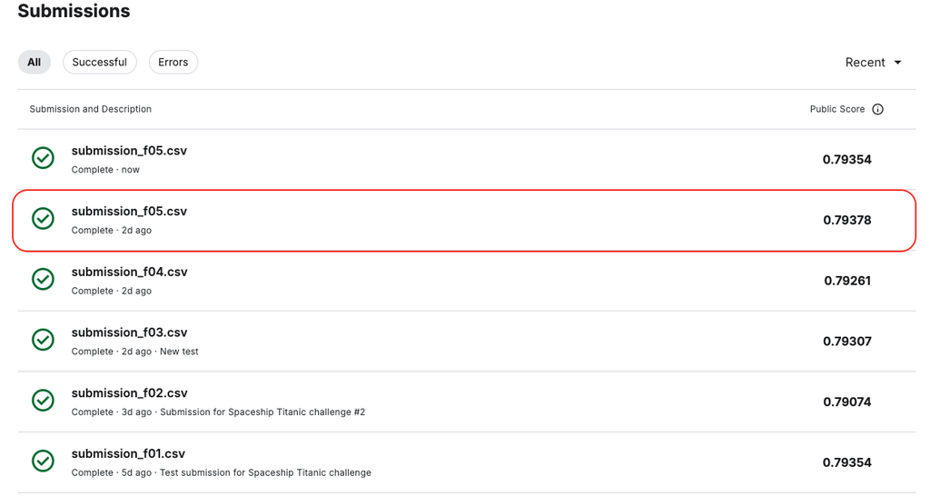

### Suggested Improvements

1. Further Feature Engineering: Additional domain-specific features could be engineered to capture more granular passenger behavior. For example, creating interaction terms or binning high-spending features could provide more meaningful insights.
2. Further Hyperparameter Fine-tuning with Bayesian Optimization: Bayesian optimization could be employed to explore hyperparameters more efficiently than grid search or random search, potentially finding an optimal configuration with fewer evaluations.